# Week 01 solutions

Caio Geraldes

## Exercice 1

*Suppose the globe tossing data (Lecture 2, Chapter 2) had turned out to be 4 water and 11 land. Construct the posterior distribution.*

### Answer

Using Grid Approximation:

```r
grid_approximation_pW <- function(W, L, size) {
    N <- W + L
    p_grid <- seq(from = 0, to = 1, length.out = size)
    prior <- rep(1, size)
    likelihood <- dbinom(W, size = N, prob = p_grid)
    unstd_post <- likelihood * prior
    posterior <- unstd_post / sum(unstd_post)
    tibble(p = p_grid, post = posterior)
}
```

```r
size <- 100
W <- 4
L <- 11

model <- grid_approximation_pW(W, L, size)
model
```

| p | post |
| --- | --- |
| 0.00000000 | 0.000000e+00 |
| 0.01010101 | 2.053886e-06 |
| 0.02020202 | 2.935611e-05 |
| 0.03030303 | 1.326045e-04 |
| 0.04040404 | 3.734987e-04 |
| 0.05050505 | 8.116633e-04 |
| 0.06060606 | 1.496260e-03 |
| 0.07070707 | 2.461205e-03 |
| 0.08080808 | 3.723101e-03 |
| 0.09090909 | 5.281134e-03 |

[output cut: 90 more lines]

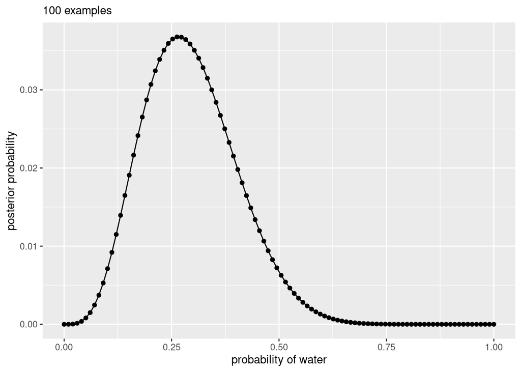

```r
model %>%
  ggplot(aes(x = p, y = post)) +
  geom_line() + geom_point() +
  xlab("probability of water") +
  ylab("posterior probability") +
  labs(subtitle = str_c(as.character(size), " examples"))
```

## Exercice 2:

*Using the posterior distribution from 1, compute the posterior predictive distribution for the next 5 tosses of the same globe. I recommend you use the sampling method.*

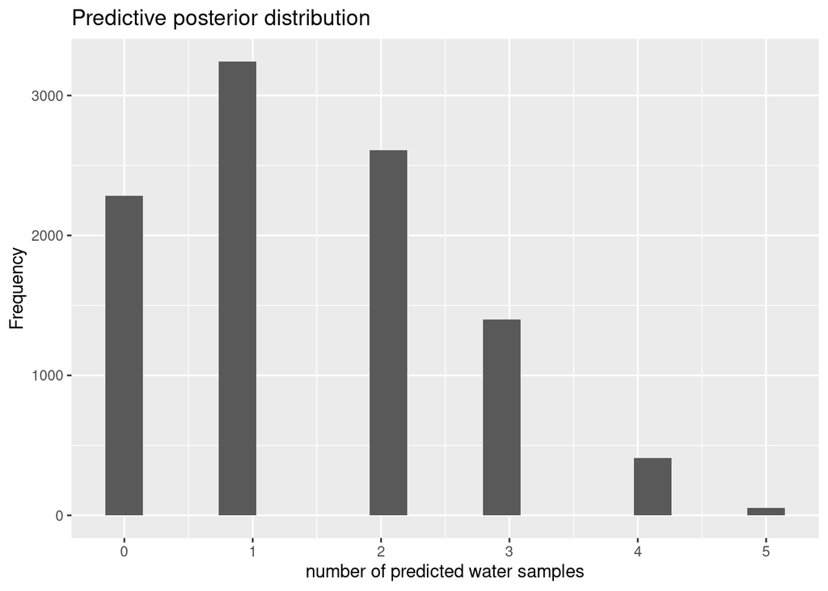

```r
n_simulations <- 1e4
sample_size <- 5
p_grid <- seq(from = 0, to = 1, length.out = size)

post_samples <- sample(
   p_grid,
   size = n_simulations,
   replace = TRUE,
   prob = model$post
)

w_pred <- rbinom(
  n_simulations,
  size = sample_size,
  prob = post_samples
)

tibble(w_pred) %>%
  ggplot(aes(x = w_pred)) +
  geom_histogram(bins = 18) +
  xlab("number of predicted water samples") +
  ylab("Frequency") +
  labs(title = "Predictive posterior distribution")
```

## Exercice 3

*Use the posterior predictive distribution from 2 to calculate the probability of 3 or more water samples in the next 5 tosses.*

```r
sum(w_pred >= 3) / n_simulations
```

```
## [1] 0.1866
```

## Exercice 4

*This problem is an optional challenge for people who are taking the course for a second or third time. Suppose you observe W = 5 water points, but you forgot to write down how many times the globe was tossed, so you don’t know the number of land points L. Assume that p = 0.7 and compute the posterior distribution of the number of tosses N. Hint: Use the binomial distribution.*

### Answer

The probability of round of tosses having $N$ tosses can be approximated with a Grid Approximation, just like the probability of water $p_W$ was in the last exercises. Since the limit of $N$ is $1...\infty$ and N must be an integer, in contrast to $p_W$’s $0...1$, the grid can not be expressed by non-integer values and must have an upper bound $N_{max}$.

The Grid Approximation for a range of tosses is produced with help of the functions `make_n_grid` and `grid_approximation_tosses`:

```r
make_n_grid <- function(W, N_max) {
  seq(from = W, to = N_max, length.out = (N_max - W + 1))
}

grid_approximation_tosses <- function(W, p_W, N_max) {
  n_grid <- make_n_grid(W, N_max)
  likelihood_w_given_n <- dbinom(W, n_grid, p_W)
  unstd_post <- likelihood_w_given_n
  posterior <- unstd_post / sum(unstd_post)
  tibble(n = n_grid, post = round(posterior,3))
}
```

In this answer we use $N_{max} = 30$, as by 20 tosses, the probability of $N$ with $p_W = 0,7$ and $W=5$ is presumably very low.

```r
N_max <- 30
W <- 5
p_W <- 0.7

model <- grid_approximation_tosses(W, p_W, N_max)
model
```

| n | post |
| --- | --- |
| 5 | 0.118 |
| 6 | 0.212 |
| 7 | 0.222 |
| 8 | 0.178 |
| 9 | 0.120 |
| 10 | 0.072 |
| 11 | 0.040 |
| 12 | 0.020 |
| 13 | 0.010 |
| 14 | 0.005 |

[output cut: 16 more lines]

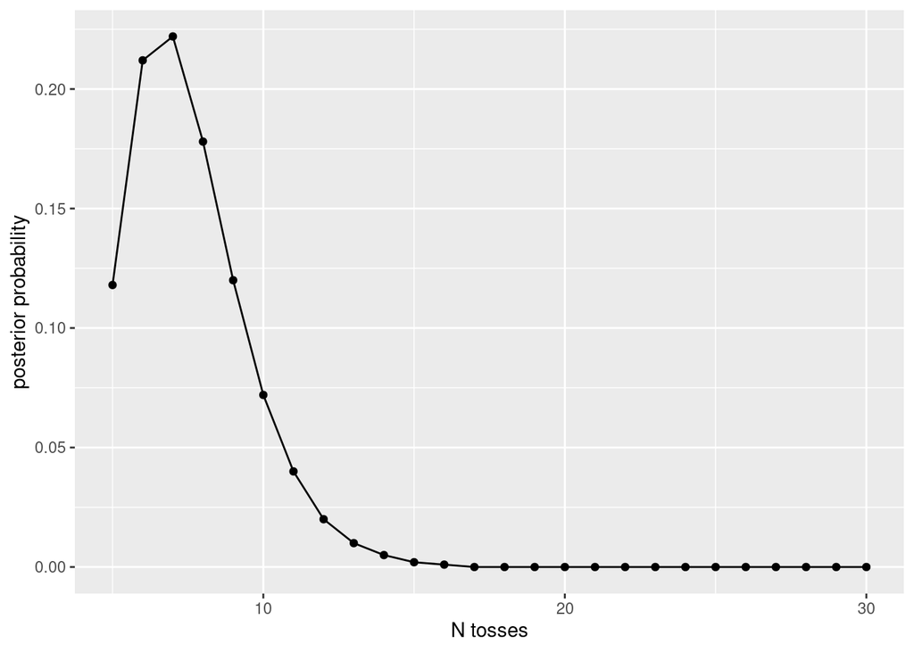

Drawing $10.000$ samples from the posterior distribution:

```r
n_simulations <- 1e4
n_grid <- make_n_grid(W, N_max)
post_samples <- sample(
   n_grid,
   size = n_simulations,
   replace = TRUE,
    prob = model$post
)
hpdi <- HPDI(post_samples)
hpdi
```

```
## |0.89 0.89|
##     5    10
```

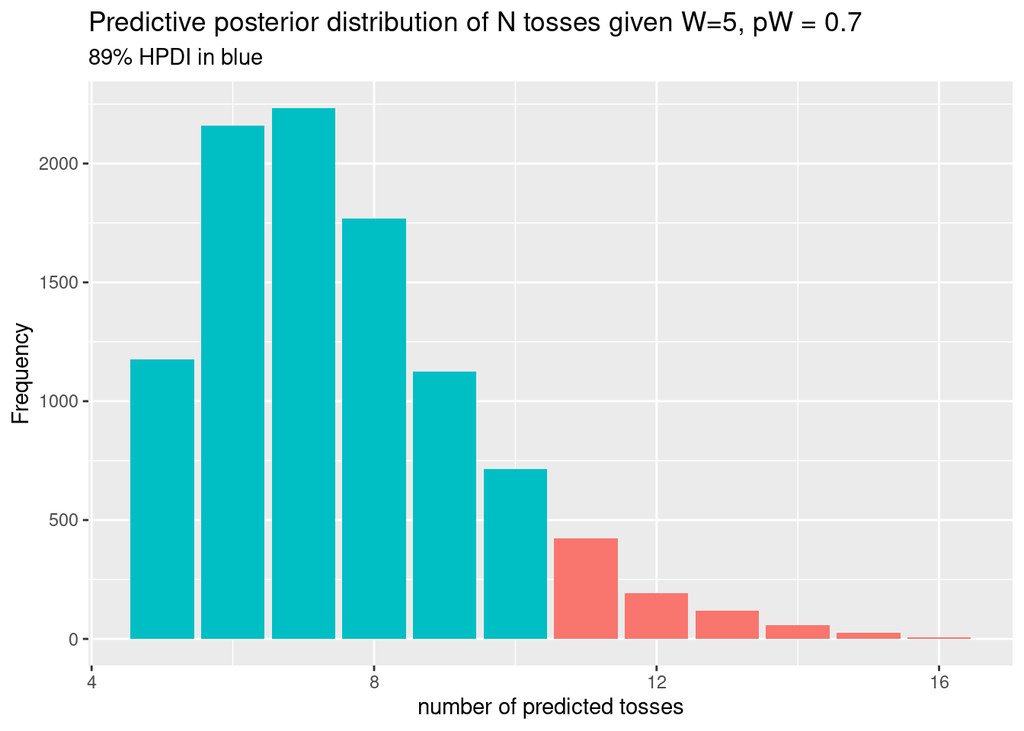

### Testing

To test the model, we will assume a longer tossing run, with $W=50$ and a $N_{max} = 100$:

```r
N_max <- 100
W <- 50
p_W <- 0.7

model <- grid_approximation_tosses(W, p_W, N_max)
model
```

| n | post |
| --- | --- |
| 50 | 0.000 |
| 51 | 0.000 |
| 52 | 0.000 |
| 53 | 0.000 |
| 54 | 0.000 |
| 55 | 0.000 |
| 56 | 0.000 |
| 57 | 0.001 |
| 58 | 0.002 |
| 59 | 0.003 |

[output cut: 41 more lines]

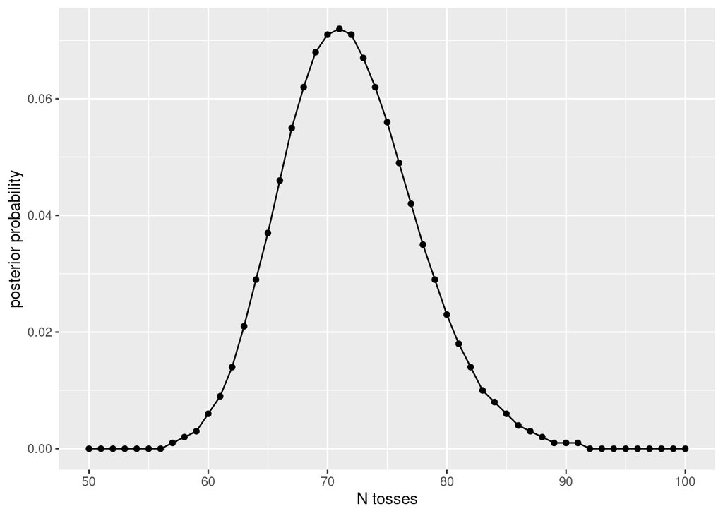

Drawing $10.000$ samples from the posterior distribution:

```r
n_simulations <- 1e4
n_grid <- make_n_grid(W, N_max)
post_samples <- sample(
   n_grid,
   size = n_simulations,
   replace = TRUE,
    prob = model$post
)

hpdi <- HPDI(post_samples)
hpdi
```

```
## |0.89 0.89|
##    63    80
```

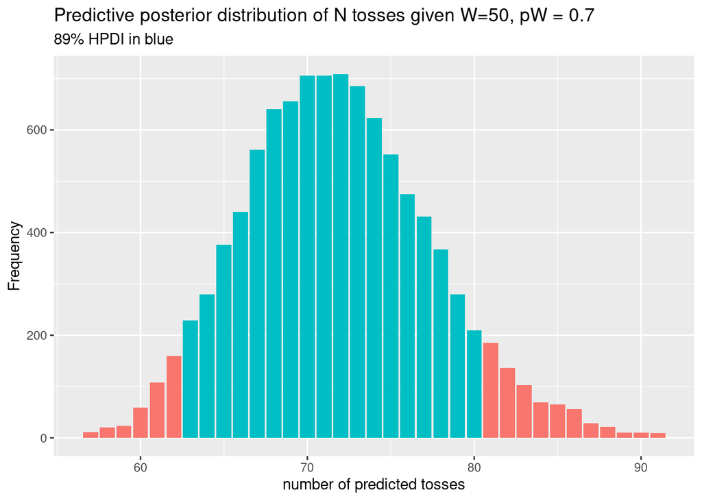

By changing $p_W$ for a value lower than $0.5$, say $p_W = 0.3$, the likelihood of longer tossing runs increases:

```r
N_max <- 100
W <- 50
p_W <- 0.3

model <- grid_approximation_tosses(W, p_W, N_max)
model
```

| n | post |
| --- | --- |
| 50 | 0.000 |
| 51 | 0.000 |
| 52 | 0.000 |
| 53 | 0.000 |
| 54 | 0.000 |
| 55 | 0.000 |
| 56 | 0.000 |
| 57 | 0.000 |
| 58 | 0.000 |
| 59 | 0.000 |

[output cut: 41 more lines]

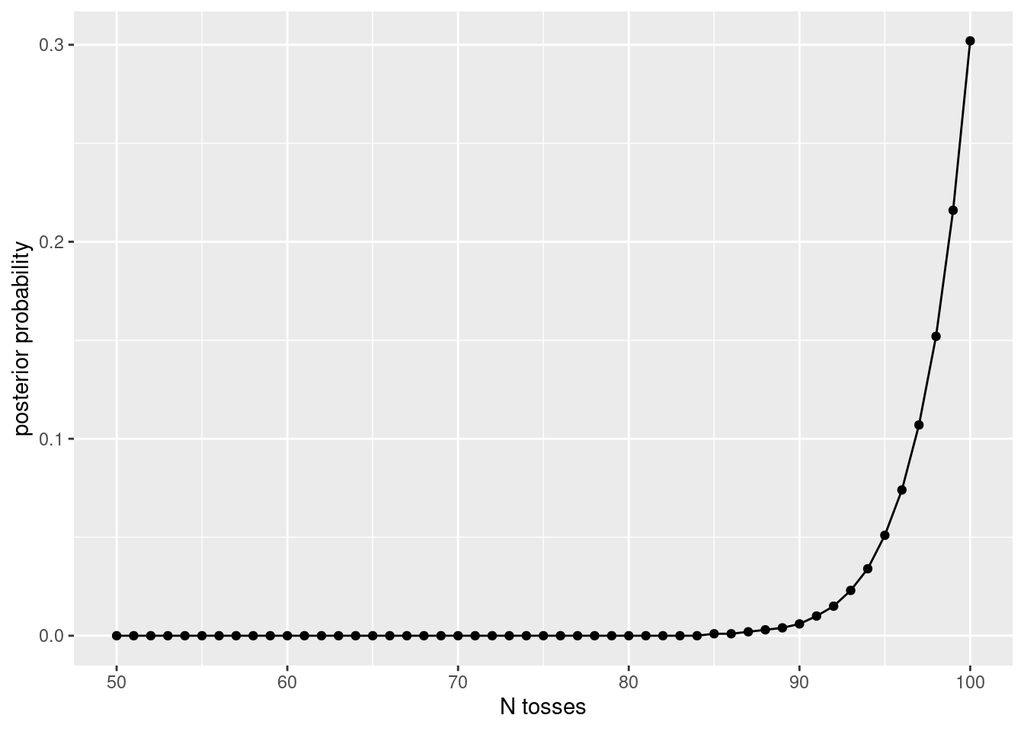

Drawing $10.000$ samples from the posterior distribution:

```r
n_simulations <- 1e4
n_grid <- make_n_grid(W, N_max)
post_samples <- sample(
   n_grid,
   size = n_simulations,
   replace = TRUE,
    prob = model$post
)
hpdi <- HPDI(post_samples)
hpdi
```

```
## |0.89 0.89|
##    95   100
```

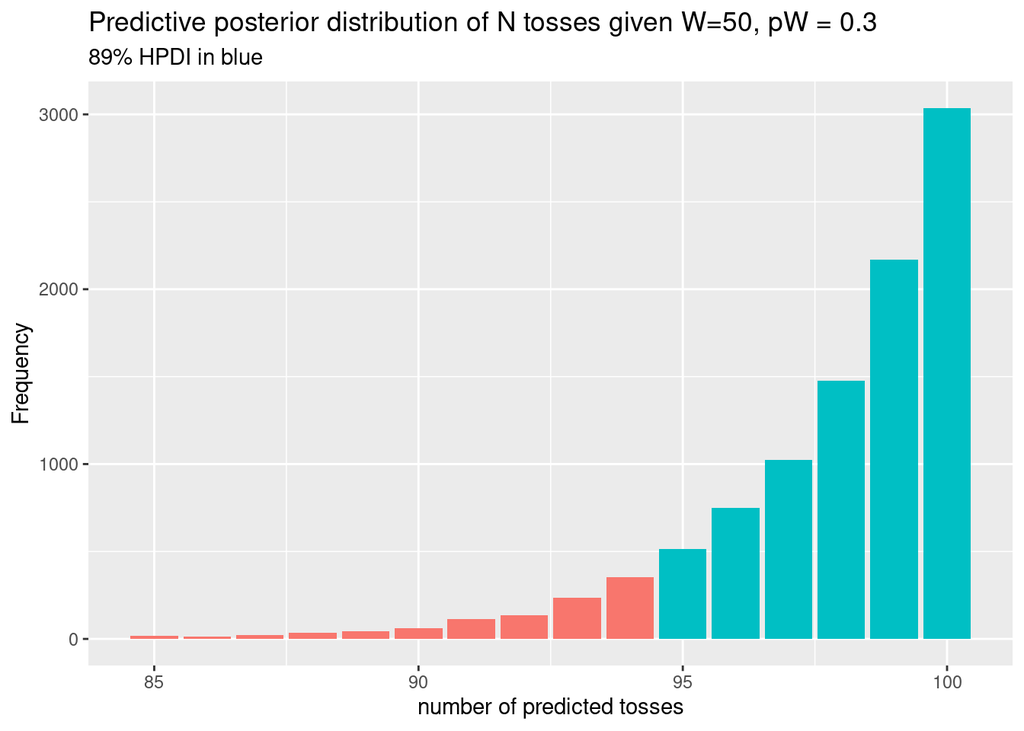